# Spectral Estimation Time Series

Veera Marni

## Question 2

```r
CBEData= read.table("~/gdrive/IUBCourseWork/TimeSeries/Introductory Time Series with R-Paul S.P. Cowpertwait and Andrew Viggo Metcalfe/data/cbe.dat", header = T)

# using only a sample of the total data -- Electricity
attach(CBEData)

elec = CBEData$elec - mean(CBEData$elec)
choc = CBEData$choc - mean(CBEData$choc)
ec = cbind(elec, choc)
N = 396

# FFT
PlotFFT <- function(values){
  values_fft = fft(values)
  n2 = 1:(N/2)
  values_fft = values_fft[n2]
  values_fft = abs(values_fft)^2
  values_fft = values_fft/sum(values_fft)
  values_fft = values_fft/sum(values_fft)
  plot(n2/N,values_fft,type="l",xlab="Frequency", ylab = "Spectrum")
  # print(which(values_fft==max(values_fft)))
}

# Dtrend
DT<- function(values,f)  {
  time <- 1:length(values)
  s1 = cos(2*pi*time*(f))
  s2 = sin(2*pi*time*(f))
  T2 = time*time
  reg <- lm(values ~ time+T2+s1+s2)
  return (reg)
}
```

Before detrending the 2 measures electricity and chocolate

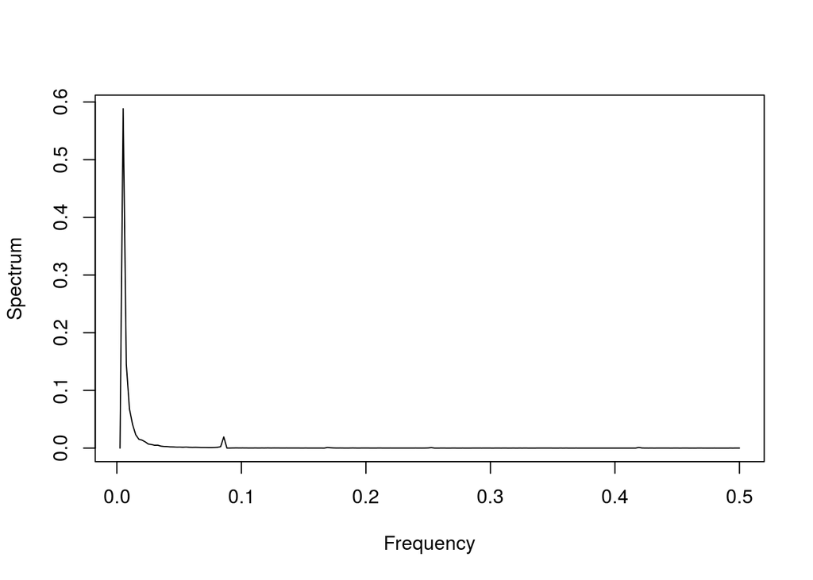

```r
PlotFFT(elec)
```

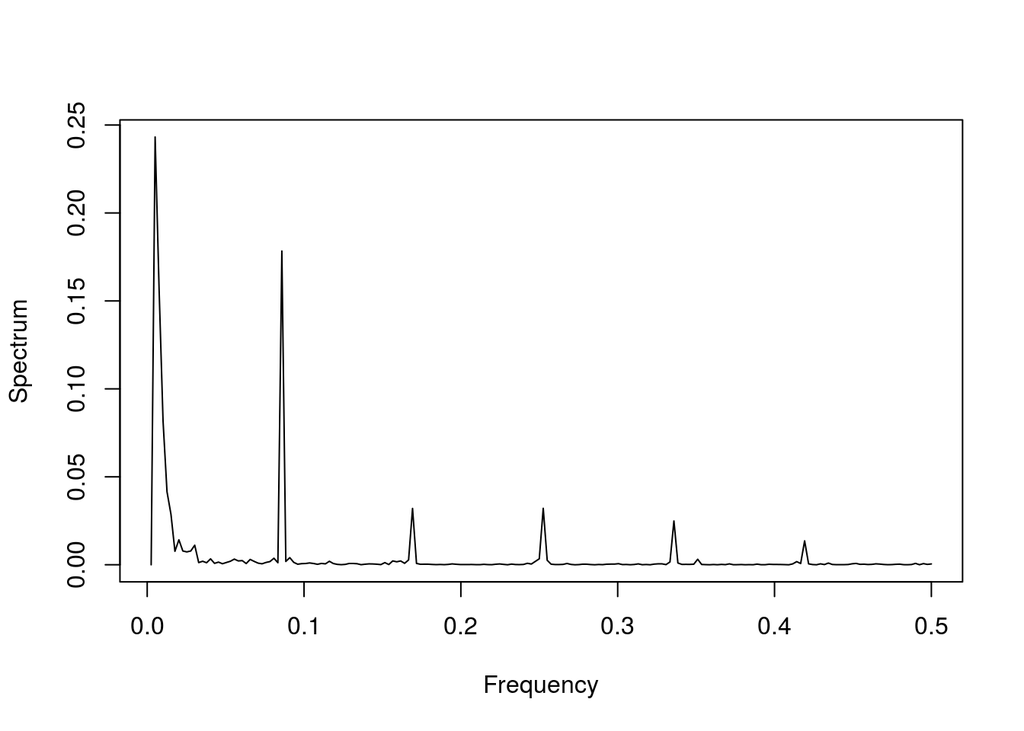

```r
PlotFFT(choc)
```

### Electricity

After detrending electricity for frequencies = {2/396, 33/396}. We can notice the magnitudes falling in spectrum

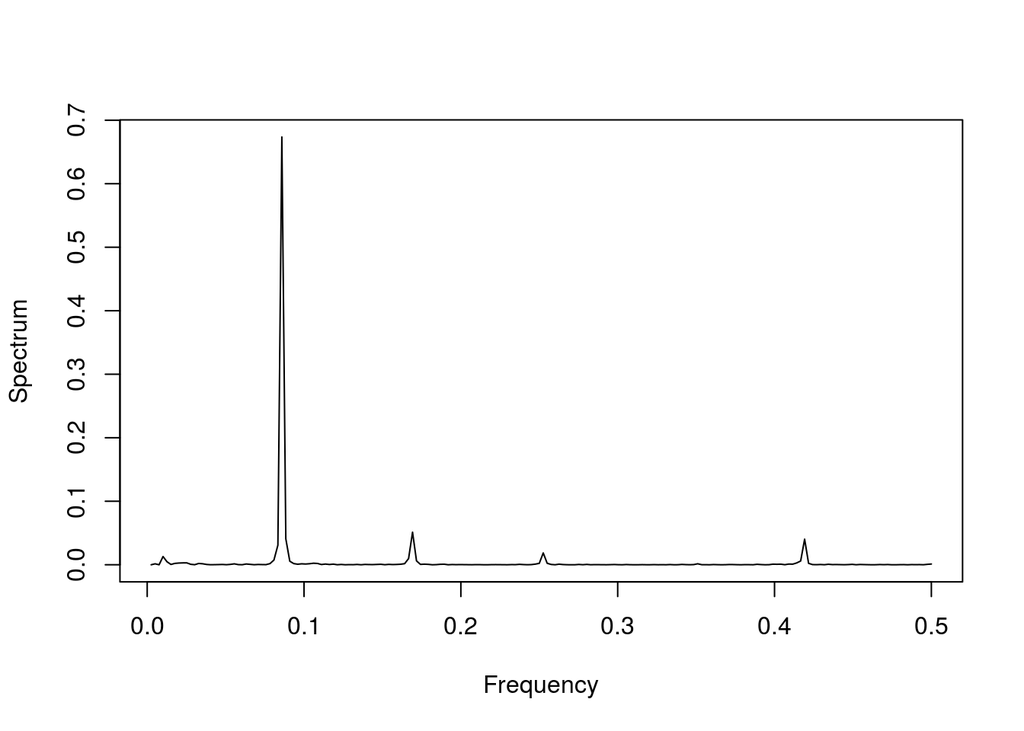

```r
elec_reg <- DT(elec, f=(2/N))
PlotFFT(elec_reg$residuals)
```

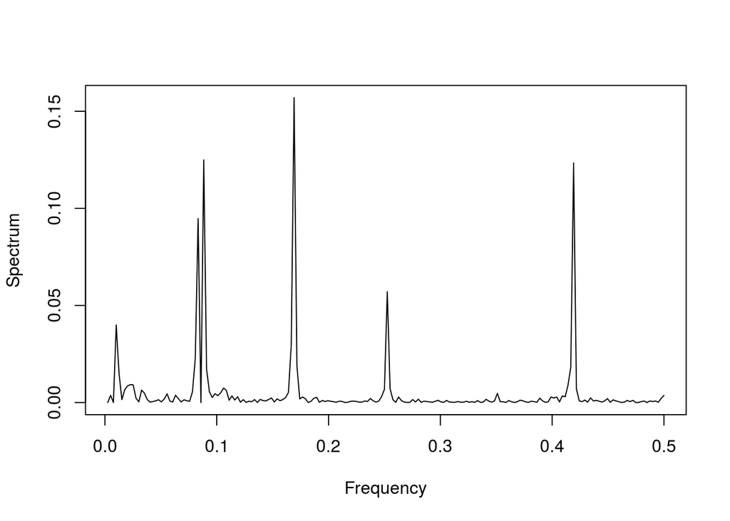

```r
elec_reg <- DT(elec_reg$residuals, f=(33/N))
PlotFFT(elec_reg$residuals)
```

### Chocolate

After detrending chocolate for frequencies = {2/396, 33/396}. We can notice the magnitudes falling in spectrum

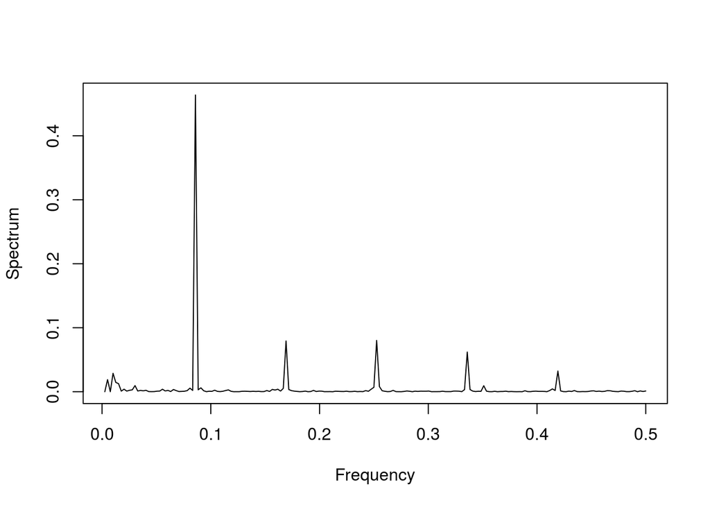

```r
choc_reg <- DT(choc, f=(2/N))
PlotFFT(choc_reg$residuals)
```

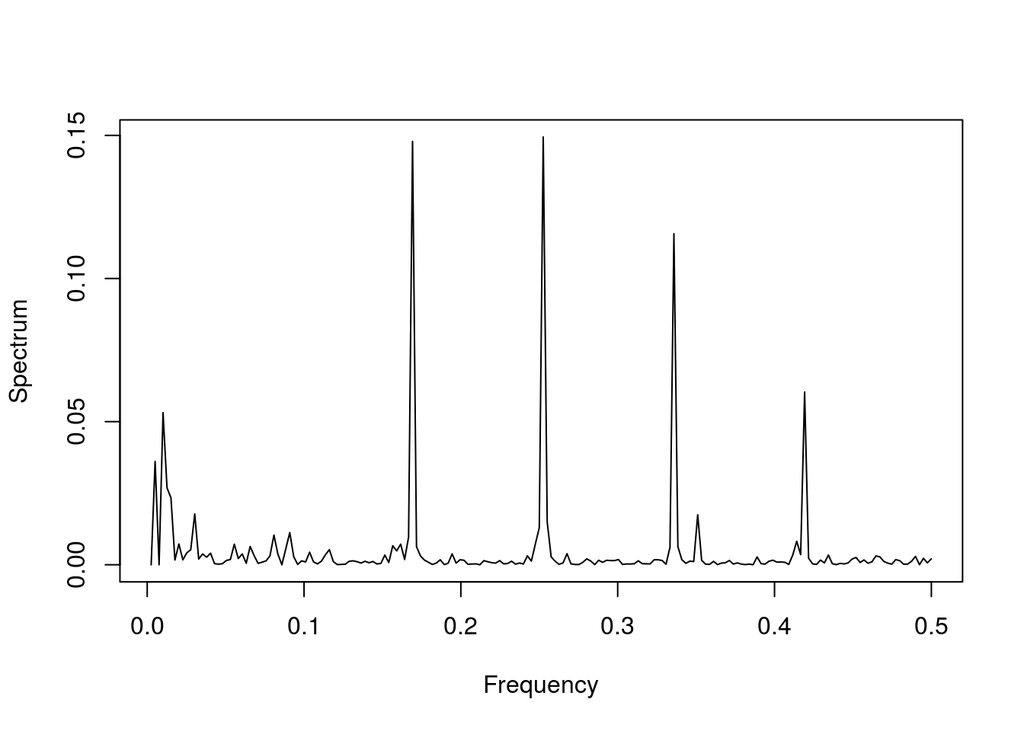

```r
choc_reg <- DT(choc_reg$residuals, f=(33/N))
PlotFFT(choc_reg$residuals)
```

## Question 3

### Electricity

without window

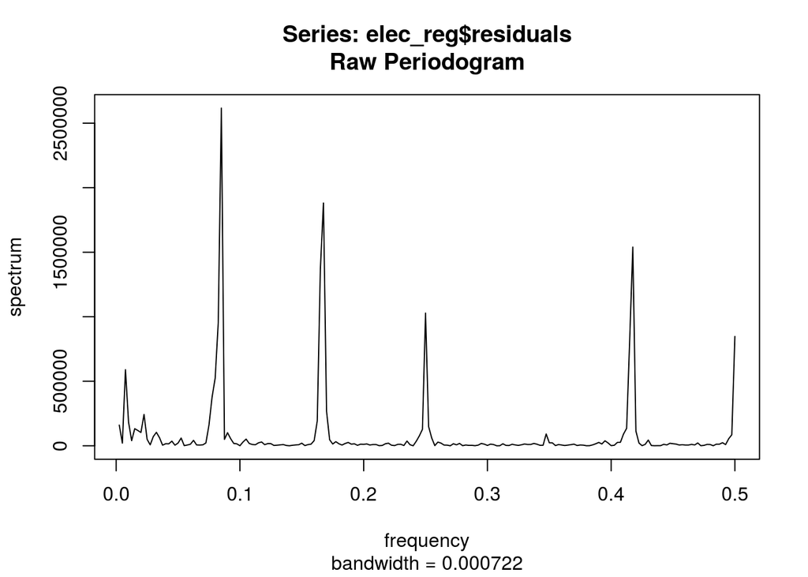

```r
spec.pgram(elec_reg$residuals,log="no")
```

with window size = 7 :Reason: I choose 7 as window size as it removes the the noise(power of unwanted frequencies) and still retains the power of important frequencies in the plot

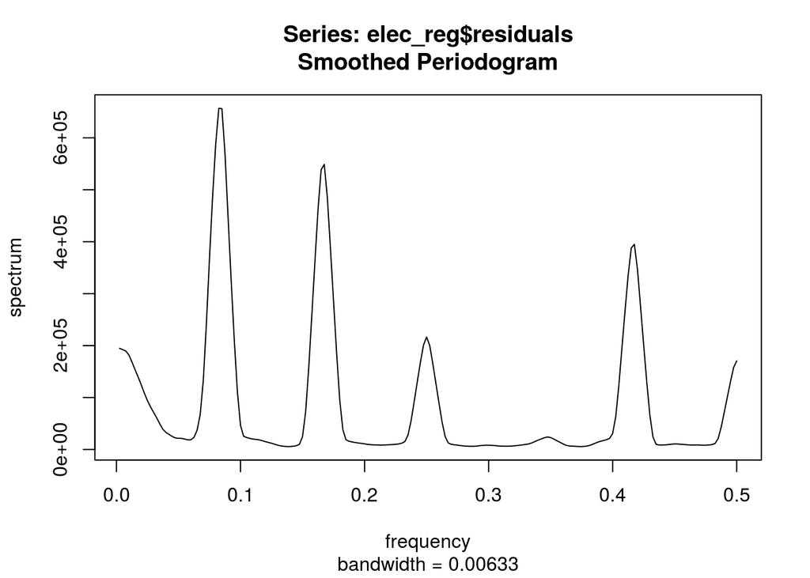

```r
spec.pgram(elec_reg$residuals,spans=c(7,7),log="no")
```

### Chocolate

without window

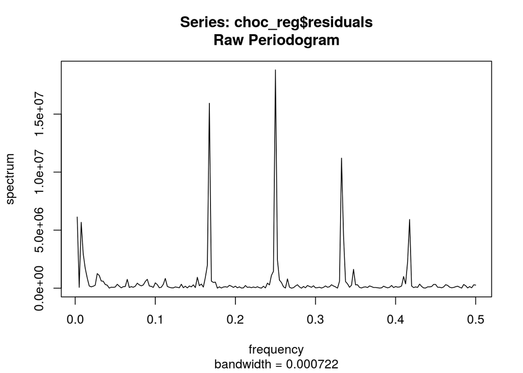

```r
spec.pgram(choc_reg$residuals,log="no")
```

with window size = 10 :Reason: I choose 10 as window size as it removes the the noise(power of unwanted frequencies) and still retains the power of important frequencies in the plot

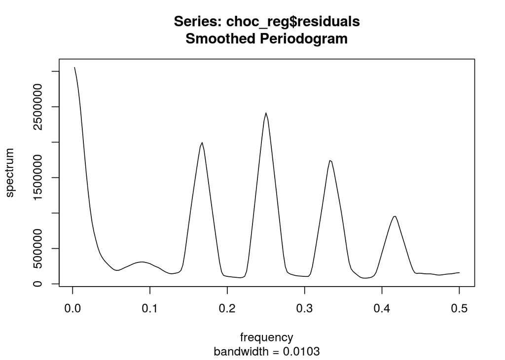

```r
spec.pgram(choc_reg$residuals,spans=c(10,10),log="no")
```

## Question 4

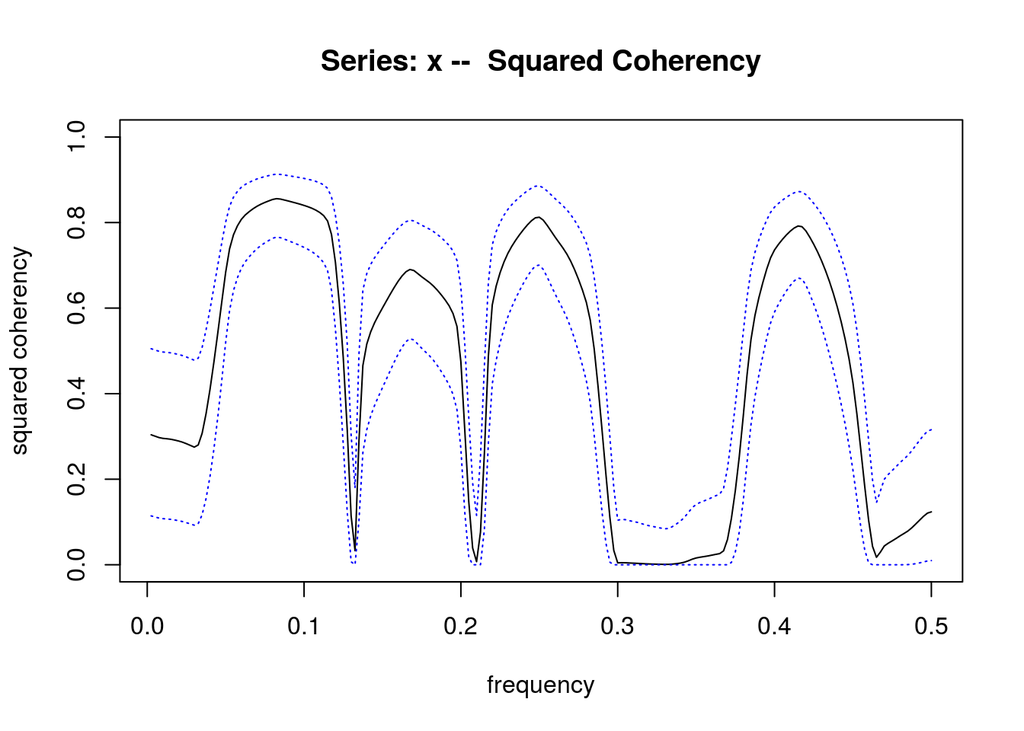

```r
X=cbind(elec, choc)
H = spectrum(X,spans=c(20,20),plot.type="coherency")
```